# R Notebook

Initial look at data visualisation suggests models will not perform particuarly well at this stage.

However, there are plenty of things that could be tried with more promising data.

For example:

- Regression model to look at relative influence of different factors on total spend?
- Unsupervised clustering algorithm to detect “groups” of customer profile that may spend differently?

This notebook has a very first look at kmeans clustering for customer segmentation.

Customer Segmentation is the subdivision of a market into discrete customer groups that share similar characteristics. Customer Segmentation can be a powerful means to identify unsatisfied customer needs. Using the above data companies can then outperform the competition by developing uniquely appealing products and services.

Ways in which businesses segment their customer base include: 1. Demographic information, such as gender, age, familial and marital status, income, education, and occupation. 2. Geographical information, which differs depending on the scope of the company. For localized businesses, this info might pertain to specific towns or counties. For larger companies, it might mean a customer’s city, state, or even country of residence. 3. Psychographics, such as social class, lifestyle, and personality traits. 4. Behavioral data, such as spending and consumption habits, product/service usage, and desired benefits.

Advantages of Customer Segmentation *Determine appropriate product pricing.* Develop customized marketing campaigns. *Design an optimal distribution strategy.* Choose specific product features for deployment. *Prioritize new product development efforts.

Install following packages if you don’t have them

```r
library("tidyverse")
library("scatterplot3d")
```

Read in data

```r
clarks <- read.csv("data/Data\ Science\ Assessment.csv")
```

```r
clarks <-  mutate(clarks,
                  total.spend = online.spend + store.spend)
clarks$email <- as.numeric(clarks$email=="yes")
clarks[,3:14] <- scale(clarks[,3:14])
```

3 clusters

```r
set.seed(20)
clusters3 <- kmeans(clarks[,c(3:6)], 3)
clarks$clusters3 <- as.factor(clusters3$cluster)
str(clusters3)
```

```
List of 9
 $ cluster     : int [1:100000] 3 3 2 3 1 2 2 3 3 3 ...
 $ centers     : num [1:3, 1:4] 0.64156 0.0064 -0.65047 0.64565 -0.00253 ...
  ..- attr(*, "dimnames")=List of 2
  .. ..$ : chr [1:3] "1" "2" "3"
  .. ..$ : chr [1:4] "age" "credit.score" "email" "distance.to.store"
 $ totss       : num 4e+05
 $ withinss    : num [1:3] 82315 86595 73384
 $ tot.withinss: num 242294
 $ betweenss   : num 157702
 $ size        : int [1:3] 35224 29742 35034
 $ iter        : int 3
 $ ifault      : int 0
 - attr(*, "class")= chr "kmeans"
```

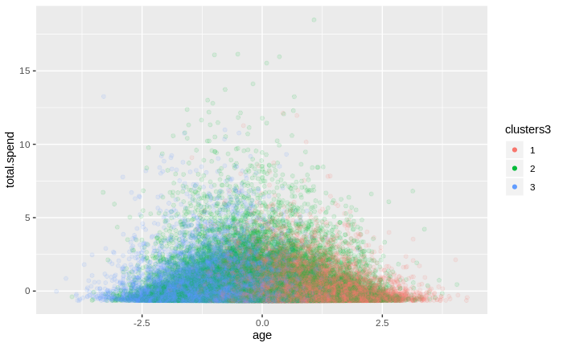

```r
 ggplot(data = clarks, aes(x = age, y = total.spend, colour = clusters3)) +
          geom_point(alpha = 0.1)+ guides(colour = guide_legend(override.aes = list(alpha = 1)))
```

4 clusters

```r
set.seed(20)
clusters4 <- kmeans(clarks[,c(3:6)], 4)
clarks$clusters4 <- as.factor(clusters4$cluster)
str(clusters4)
```

```
List of 9
 $ cluster     : int [1:100000] 3 3 2 3 1 2 2 3 3 3 ...
 $ centers     : num [1:4, 1:4] 6.41e-01 6.67e-03 -6.50e-01 7.11e-05 6.48e-01 ...
  ..- attr(*, "dimnames")=List of 2
  .. ..$ : chr [1:4] "1" "2" "3" "4"
  .. ..$ : chr [1:4] "age" "credit.score" "email" "distance.to.store"
 $ totss       : num 4e+05
 $ withinss    : num [1:4] 50161 63605 50026 31846
 $ tot.withinss: num 195638
 $ betweenss   : num 204358
 $ size        : int [1:4] 34347 29073 34161 2419
 $ iter        : int 4
 $ ifault      : int 0
 - attr(*, "class")= chr "kmeans"
```

5 clusters

```r
set.seed(20)
clusters5 <- kmeans(clarks[,c(3:6)], 5)
clarks$clusters5 <- as.factor(clusters5$cluster)
str(clusters5)
```

```
List of 9
 $ cluster     : int [1:100000] 3 3 5 3 2 5 5 3 3 3 ...
 $ centers     : num [1:5, 1:4] -0.536668 1.055628 -0.549564 -0.001056 -0.000623 ...
  ..- attr(*, "dimnames")=List of 2
  .. ..$ : chr [1:5] "1" "2" "3" "4" ...
  .. ..$ : chr [1:4] "age" "credit.score" "email" "distance.to.store"
 $ totss       : num 4e+05
 $ withinss    : num [1:5] 20912 31407 32216 30960 60454
 $ tot.withinss: num 175949
 $ betweenss   : num 224047
 $ size        : int [1:5] 21596 23458 23933 2308 28705
 $ iter        : int 4
 $ ifault      : int 0
 - attr(*, "class")= chr "kmeans"
```

Note: there are established methods for choosing optimum number of clusters - most prominently Elbow, Silhouhette and Gap statistic methods. Note: here I have used all data - would want to use a taining subset in reality.

Quick example of output:

Clustering was done on age, credit score, distance and email (age and credit score are loosely correlates so we will just plot age)

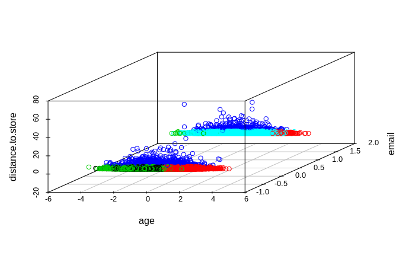

```r
scatterplot3d( clarks[,c(3,5,6)], color = as.numeric(clarks$clusters5))
```

If we remove email and instrad plot total spend we can see if our clusters have any relationship to total.spend - perhaps a little?

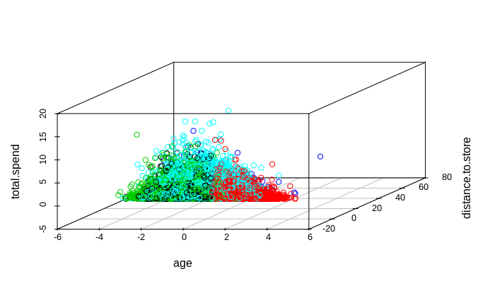

```r
scatterplot3d( clarks[,c(3,6,14)], color = as.numeric(clarks$clusters5))
```

We could explore other clustering algorithms. We could also look at regression or support vector machines to try to determine which factors effect total.spend and profile customers in this way. We could also try using data we collect to predict if customers will be online only, store only or both which could feed into other recomendations